# Returns Distributions

Ben Gilbert

9/1/2021

# Returns Distributions Analysis

## Overview

- Skills covered:
  - Setting working directory
  - Computing summary statistics with fBasics package
  - Running t-tests for mean return, skewness and kurtosis
  - Performing Jarque-Bera (JB) test for normality
  - Using cbind() function to create new data frames
  - Visualizing return distributions

## 1. Environment Setup

### Loading Required Packages

Load (and install if necessary) any packages that we want to use. If we want to define a working directory for this session, we can.

```r
# install.packages("fBasics") # Uncomment to install if needed
library(fBasics)              # For statistical analysis
# install.packages("quantmod") # Uncomment to install if needed
library(quantmod)             # For financial data and returns calculation

# Alternative package loading approach using pacman
# if(!require(pacman))install.packages("pacman")
# pacman::p_load(fBasics, quantmod)

# Set working directory
setwd("C:/Users/gilbe/Dropbox/Econometrics/TimeSeriesCourse")
```

## 2. Financial Data Analysis

### 2.1 Market Indices

First, we’ll fetch and analyze market indices data using the quantmod package.

```r
# Create a function to plot price and return charts with proper formatting
plot_security_data = function(ticker_data, ticker_name) {
  chartSeries(ticker_data, type=c("line"), theme="white", TA=NULL,
             main=paste(ticker_name, "Price"))
}

# Fetch ETF representing energy sector
getSymbols("XLE", from="2000-01-03")
```

```
## [1] "XLE"
```

```r
# XLE is symbol for the SPDR Energy ETF

# Examine data structure
dim(XLE)  # See dimensions of dataset
```

```
## [1] 6353    6
```

```r
head(XLE) # See first six rows
```

```
##            XLE.Open XLE.High XLE.Low XLE.Close XLE.Volume XLE.Adjusted
## 2000-01-03 27.31250 27.31250 26.3750  26.56250     380300     13.73921
## 2000-01-04 26.31250 26.31250 25.8750  26.06250     722200     13.48058
## 2000-01-05 26.12500 26.75000 26.0000  26.75000     337800     13.83619
## 2000-01-06 26.75000 27.84375 26.7500  27.78125     133100     14.36959
## 2000-01-07 27.68750 28.40625 27.6875  28.07812     468000     14.52315
## 2000-01-10 28.07812 28.07812 27.6250  27.84375     122100     14.40192
```

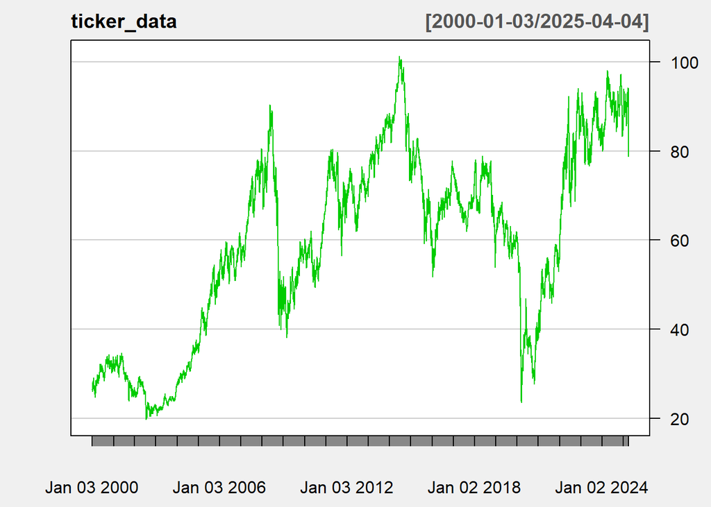

```r
# Visualize price data
plot_security_data(XLE, "SPDR Energy ETF (XLE)")
```

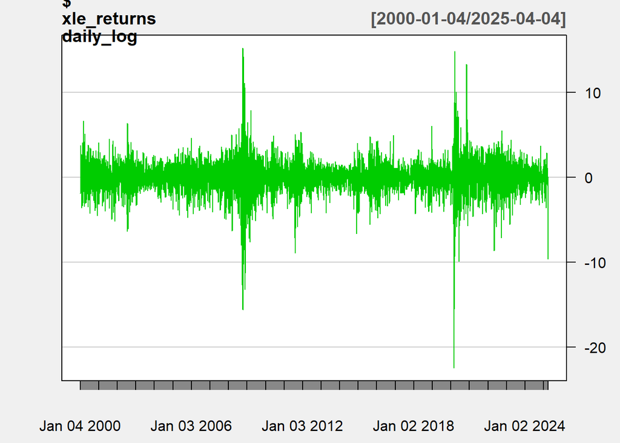

```r
# Create a function to calculate different types of returns
calculate_returns = function(symbol_data) {
  returns = list(
    daily_simple = 100*dailyReturn(symbol_data, leading=FALSE, type='arithmetic'),
    daily_log = 100*dailyReturn(symbol_data, leading=FALSE, type='log'),
    monthly_simple = 100*monthlyReturn(symbol_data, leading=FALSE, type='arithmetic'),
    monthly_log = 100*monthlyReturn(symbol_data, leading=FALSE, type='log')
  )
  return(returns)
}

# Calculate returns for XLE
xle_returns = calculate_returns(XLE)

# Visualize returns
chartSeries(xle_returns$daily_log, type=c("line"), theme="white", TA=NULL,
           main="XLE Daily Log Returns")
```

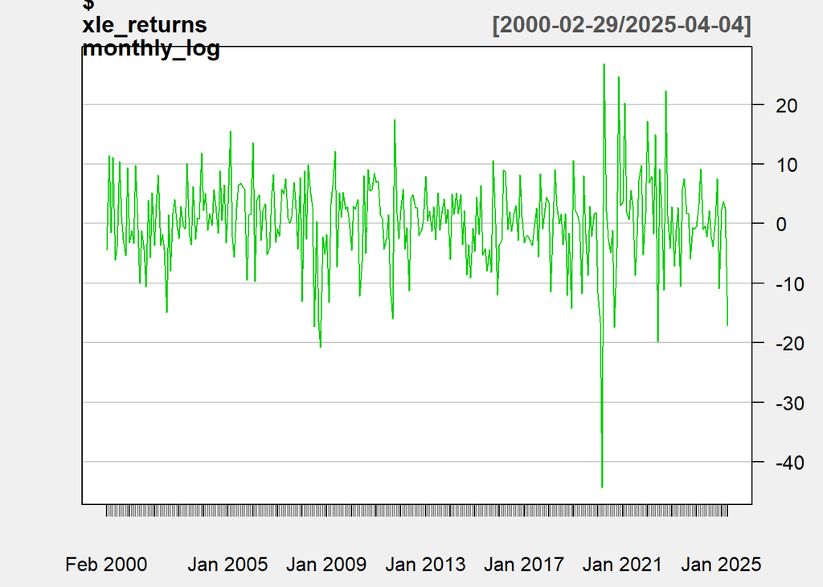

```r
chartSeries(xle_returns$monthly_log, type=c("line"), theme="white", TA=NULL,
           main="XLE Monthly Log Returns")
```

```r
# Fetch S&P 500 Index ETF
getSymbols("SPY", from="2000-01-03")
```

```
## [1] "SPY"
```

```r
# SPY is the symbol for the S&P 500 Index
spy_returns = calculate_returns(SPY)
```

### 2.2 Individual Energy Stocks

Now we’ll analyze individual energy company stocks:

- SRE (Sempra Energy)
- BRK-B (Berkshire Hathaway)
- DUK (Duke Energy)

```r
# Sempra Energy
getSymbols("SRE", from="2000-01-03")
```

```
## [1] "SRE"
```

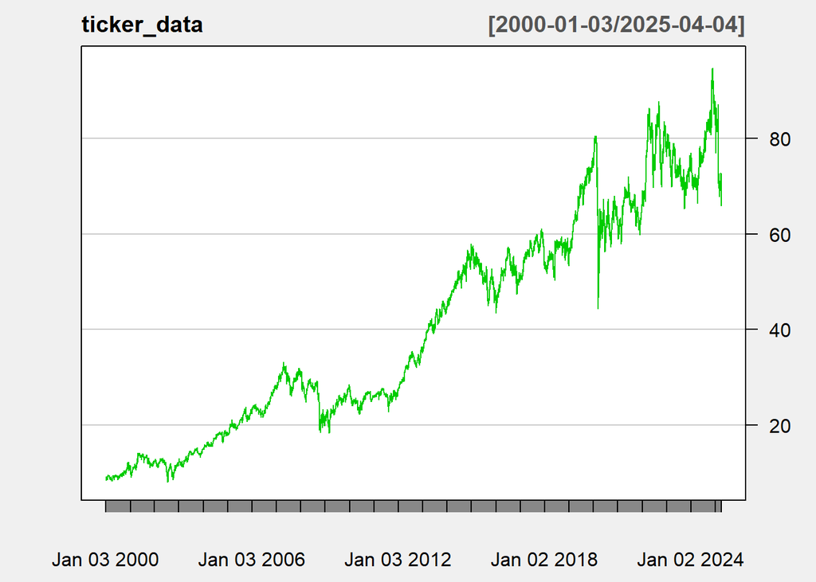

```r
plot_security_data(SRE, "Sempra Energy (SRE)")
```

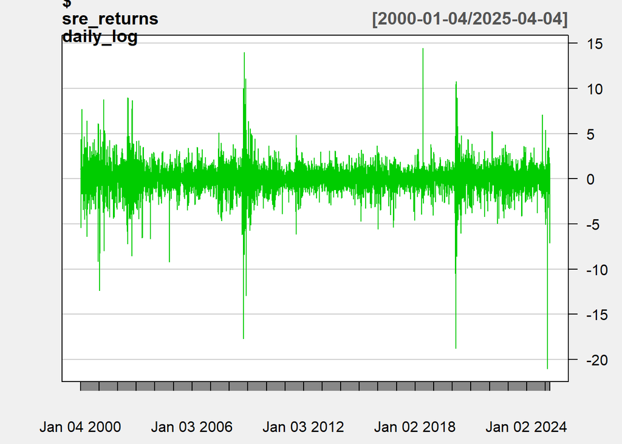

```r
sre_returns = calculate_returns(SRE)

chartSeries(sre_returns$daily_log, type=c("line"), theme="white", TA=NULL,
           main="SRE Daily Log Returns")
```

```r
# Berkshire Hathaway
# Note the quotes around "BRK-B" and `BRK-B`. Dash in name requires this.
getSymbols("BRK-B", from="2000-01-03")
```

```
## [1] "BRK-B"
```

```r
# Must use backtick quotes because of the dash in BRK-B
brk_returns = calculate_returns(`BRK-B`)

# Duke Energy
getSymbols("DUK", from="2000-01-03")
```

```
## [1] "DUK"
```

```r
duk_returns = calculate_returns(DUK)
```